# Análise da interferência da formação de florestas plantadas na área de lâmina hídrica da bacia do rio doce

João Paulo S. Gusmão

2023-04-28

### Referências

“Projeto MapBiomas – Coleção 7.1 da Série Anual de Mapas de Uso e Cobertura da Terra do Brasil, acessado em 28/04/2023 através do link: https://mapbiomas.org/metodo-agua

### Metodologia

#### MAPBIOMAS - MAPEAMENTO DO USO E COBERTURA DO SOLO

Utilizando a plataforma GEE - Google Earth Engiane através doscript “mapbiomas-user-toolkit-lulc.js” e as seguintes definição: Region: mapbiomas-brazil Collection: collection-7.1 Tables: level_2_drainage_basin Properties: name_pt_br Features: Doce Data Type: Coverage Buffer: none Layers: “Doce 1985” a “Doce 2021” Ao clicar em export images to Google Drive

Iremos na aba “Task” e clicar em “RUN” em todos os arquivos da série. Então será definido o “Drive folder” que é onde será armazenado os arquivos baixados no seu google drive.

#### MAPBIOMAS - MAPEAMENTO DA SUPERFÍCIE DE ÁGUA: SÍNTESE DO MÉTODO

https://mapbiomas.org/metodo-agua

```r
coverage <- read_csv("datasets/mapbiomas-brazil-collection-71-doce-area.csv", show_col_types = FALSE)

#Seleção de variáveis de interesse neste estudo
var_interesse <- c("ANO", "Forest Formation", "Forest Plantation", "Pasture" , "River, Lake and Ocean", "Urban Infrastructure" )
coverage <- coverage%>%select("area", 'band', 'class_name')

colnames(coverage) <- c('AREA_HA', 'ANO', 'CLASSE')
coverage$ANO <- str_replace(coverage$ANO, 'classification_', '')
coverage <- coverage %>% filter(CLASSE %in% var_interesse)
coverage <- spread(coverage, CLASSE, AREA_HA)
coverage$ANO <- as.integer(coverage$ANO)

colnames(coverage) <- c("ANO", "Formacao_Florestal", "Plantacao_Florestal", "Pasto" , "Rio_Lago_Mar", "Infraestrutura_Urbana" )
coverage
```

```
## # A tibble: 37 × 6
##      ANO Formacao_Florest… Plantacao_Flore…  Pasto Rio_Lago_Mar Infraestrutura_…
##    <int>             <dbl>            <dbl>  <dbl>        <dbl>            <dbl>
##  1  1985            27221.             494. 42893.         737.             165.
##  2  1986            26502.             547. 43520.         738.             183.
##  3  1987            26099.             601. 43798.         734.             187.
##  4  1988            25944.             775. 44087.         704.             193.
##  5  1989            25537.             846. 44367.         702.             202.
##  6  1990            25369.             860. 44689.         694.             208.
##  7  1991            25045.            1037. 44963.         727.             216.
##  8  1992            24971.            1110. 44955.         744.             222.
##  9  1993            24956.            1118. 45059.         727.             238.
## 10  1994            24917.            1192. 44660.         733.             270.
## # … with 27 more rows
```

#### MAPBIOMAS - MAPEAMENTO DA LÂMINA HÍDRICA

Utilizando a plataforma GEE - Google Earth Engiane através doscript “mapbiomas-user-toolkit-water.js” e as seguintes definições:

Iremos na aba “Task” e clicar em “RUN” em todos os arquivos da série. Então será definido o “Drive folder” que é onde será armazenado os arquivos baixados no seu google drive. Esta é a primeira coleção completa do MapBiomas Água com o mapeamento da superfície de água do Brasil de 1985 a 2020, com dados anuais e mensais para todo o período incluindo: (i) dado no ano e acumulado em um período; (ii) frequência de ocorrência; (iii) transições(ganhos e perdas) e(iv) classificação da cobertura do tipo de corpo d’água. A descrição do método de mapeamento da superfície de água e da classificação de corpos hídricos está disponível na seção de metodologias do MapBiomas. Os mapas anuais de superfície de água e as tabelas estatísticas estão disponíveis na área de download do MapBiomas. Para sugestões, críticas e ideias para aprimorar o trabalho, por favor, entre em contato pelo e- mail: contato@mapbiomas.org ou acesse o Fórum MapBiomas. Os dados do MapBiomas são públicos, abertos e gratuitos sob licença Creative Commons CC - CY - SA e mediante a referência da fonte observando o seguinte formato: “Projeto MapBiomas – Mapeamento da Superfície de Água do Brasil Coleção 1, acessado em [DATA] através do link: [LINK]”.

```r
water <- read_csv("datasets/mapbiomas-brazil-collection-10-doce-area.csv", show_col_types = FALSE)
water <- water %>% select(band, area)
colnames(water) <- c('ANO', 'WATER_COVERAGE_HA')

water$ANO <- str_replace(water$ANO, 'water_coverage_', '')
water$ANO <- as.integer(water$ANO)
```

#### REALIZANDO O JOIN DAS DUAS TABELAS OBTIDAS ATÉ ENTÃO

```r
dataset <- merge(coverage, water)
```

#### Agora temos a tabela de dados a analisar

```r
print(head(dataset, 10))
```

```
##     ANO Formacao_Florestal Plantacao_Florestal    Pasto Rio_Lago_Mar
## 1  1985           27220.82            493.7655 42892.71     736.5661
## 2  1986           26501.56            547.0175 43519.74     738.2819
## 3  1987           26099.21            601.3645 43798.18     734.3623
## 4  1988           25943.80            775.2047 44087.49     703.5857
## 5  1989           25537.15            845.5382 44366.98     702.1264
## 6  1990           25368.88            860.3498 44689.14     693.8526
## 7  1991           25045.08           1037.3587 44962.60     726.7564
## 8  1992           24971.00           1109.5070 44954.61     743.7516
## 9  1993           24955.51           1118.2121 45059.26     727.4310
## 10 1994           24917.38           1191.6558 44659.70     733.0835
##    Infraestrutura_Urbana WATER_COVERAGE_HA
## 1               165.4170          726.9543
## 2               183.1132          726.8367
## 3               186.7530          713.5045
## 4               193.0899          698.1573
## 5               201.6866          704.0752
## 6               207.5662          690.7912
## 7               215.9885          713.4486
## 8               222.3627          719.6997
## 9               237.5379          728.2891
## 10              269.5870          701.2147
```

#### Função para obter as variáveis estatísticas para análise e interpretação dos dados.

```r
analisamodelo <- function (summary){
  #Dispersion parameter for gaussian family taken to be
  dpgf <- summary$dispersion

  #Residual deviance
  rd <- summary$deviance

  #Degrees of dispersion - DF / Grau de liberdade()
  dfl <- summary$df.residual

  intercept <- summary[["coefficients"]][1]
  variavel <- summary[["coefficients"]][2][1]
  dependente <- summary[["terms"]][[2]]
  independente <- summary[["terms"]][[3]]
  relacao <-  rd/dfl
  index <- dpgf/relacao #se for próximo de 1 a relação é significatica
  equacao <- paste('y=', intercept, '+', variavel, '* x')
  return (c(Dispersion_parameter=dpgf, Residual_deviance=rd,     degrees_of_freedom=dfl, est_intercept = intercept, est_dependente=variavel, var_dependente=dependente, var_independente=independente, relacao=relacao, index=index, equacao=equacao))
}
```

#### Testando os modelos

```r
attach(dataset)
set.seed(2023)
colnames((dataset))
```

```
## [1] "ANO"                   "Formacao_Florestal"    "Plantacao_Florestal"
## [4] "Pasto"                 "Rio_Lago_Mar"          "Infraestrutura_Urbana"
## [7] "WATER_COVERAGE_HA"
```

```r
modelos = list()
```

#### 1 - Análise: Formacao_Florestal~ANO

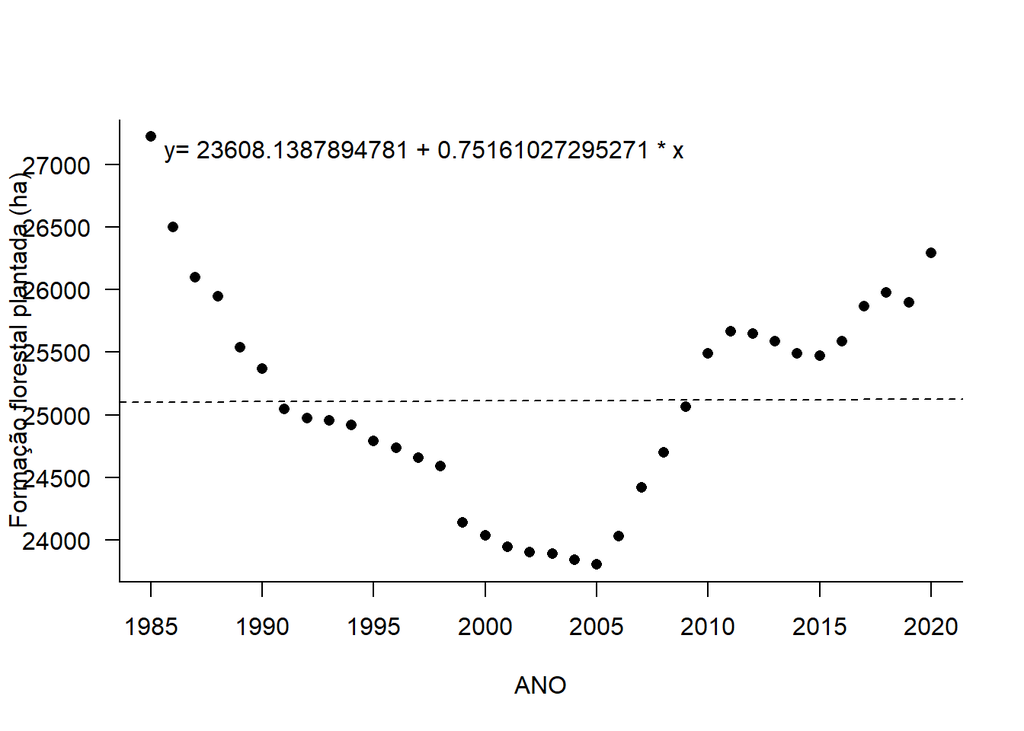

```r
m1 <- glm(Formacao_Florestal~ANO)
mnulo1 <- glm(Formacao_Florestal~1)

anova.md1 <- anova(m1, mnulo1, test='F')
summary.m1 <- summary(m1)

dt.modelo1 <- analisamodelo(summary.m1)
modelos <- append(modelos, dt.modelo1)

plot(Formacao_Florestal~ANO, ylab="Formação florestal plantada (ha)", xlab=dt.modelo1$var_independente, pch=16,las=1,bty="l")
abline(m1, lty=2)
equacao <- dt.modelo1$equacao
legend(x='topleft', legend=equacao,bty="n", )
```

#### 2 - Análise: Plantacao_Florestal~ANO

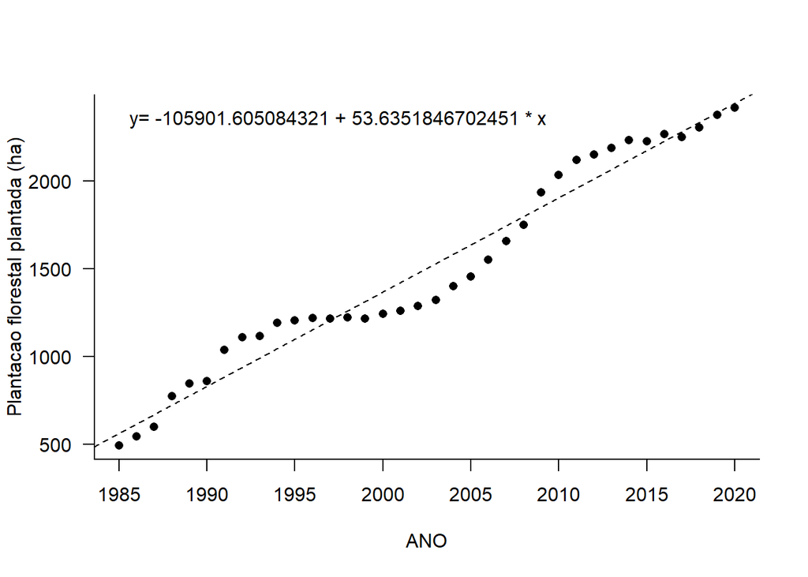

```r
m2 <- glm(Plantacao_Florestal~ANO)
mnulo2 <- glm(Plantacao_Florestal~1)

anova.md2 <- anova(m2, mnulo2, test='F')
summary.m2 <- summary(m2)

dt.modelo2 <- analisamodelo(summary.m2)
modelos <- append(modelos, dt.modelo2)

plot(Plantacao_Florestal~ANO, ylab="Plantacao florestal plantada (ha)", xlab=dt.modelo2$var_independente, pch=16,las=1,bty="l")
#curve(dt.modelo$est_intercept + dt.modelo$est_dependente*x, add=T, lty=16)
equacao <- dt.modelo2$equacao
abline(m2, lty=2)
legend(x='topleft', legend=equacao,bty="n", )
```

#### 3 - Análise: Pasto~ANO

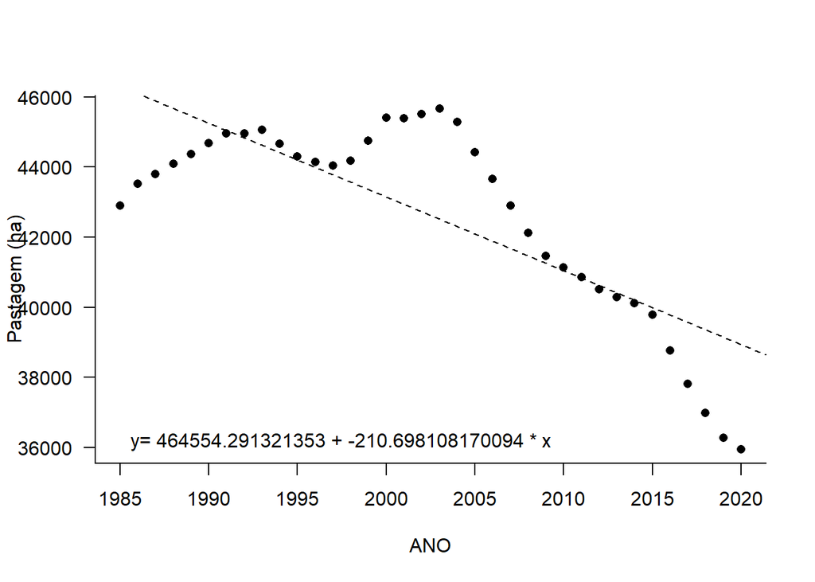

```r
m3 <- glm(Pasto~ANO)
mnulo3 <- glm(Pasto~1)

anova.md3 <- anova(m3, mnulo3, test='F')
summary.m3 <- summary(m3)

dt.modelo3 <- analisamodelo(summary.m3)
modelos <- append(modelos, dt.modelo3)

plot(Pasto~ANO, ylab="Pastagem (ha)", xlab=dt.modelo3$var_independente, pch=16,las=1,bty="l")

equacao <- dt.modelo3$equacao

abline(m3, lty=2)

legend(x='bottomleft', legend=equacao,bty="n", )
```

#### 4 - Análise: Rio_Lago_Mar~ANO

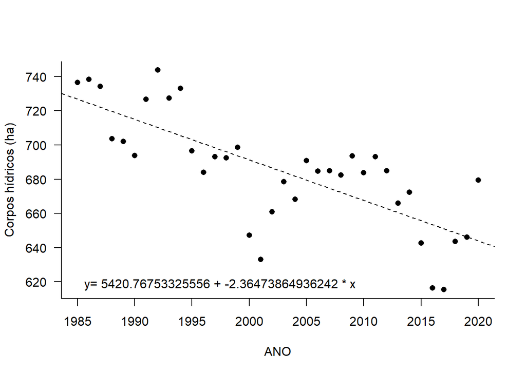

```r
m4 <- glm(Rio_Lago_Mar~ANO)
mnulo4 <- glm(Rio_Lago_Mar~1)

anova.md4 <- anova(m4, mnulo4, test='F')
summary.m4 <- summary(m4)

dt.modelo4 <- analisamodelo(summary.m4)
modelos <- append(modelos, dt.modelo4)

plot(Rio_Lago_Mar~ANO, ylab="Corpos hídricos (ha)", xlab=dt.modelo4$var_independente, pch=16,las=1,bty="l")

equacao <- dt.modelo4$equacao

abline(m4, lty=2)

legend(x='bottomleft', legend=equacao,bty="n", )
```

#### 5 - Análise: Infraestrutura_Urbana~ANO

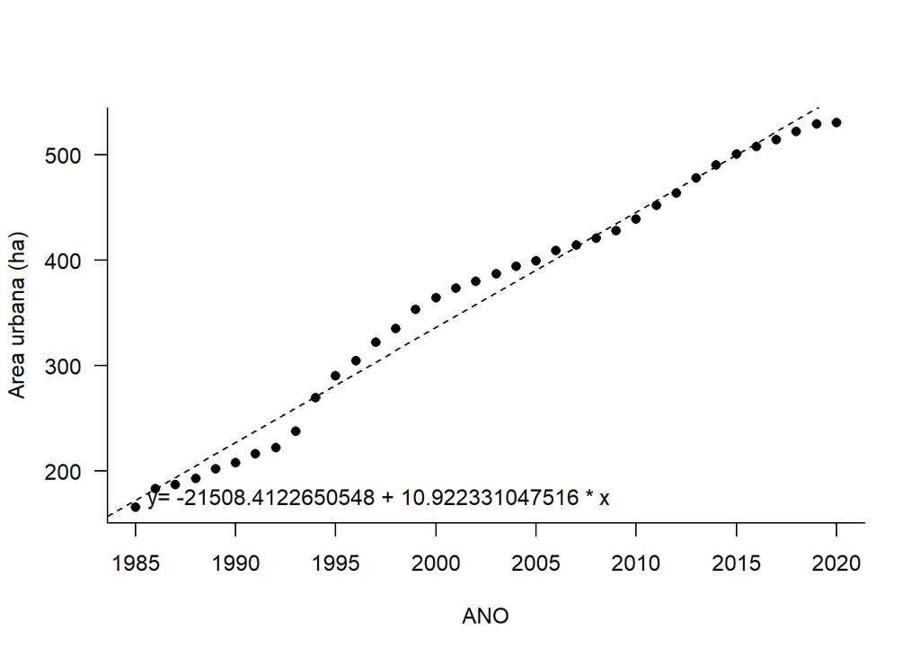

```r
m5 <- glm(Infraestrutura_Urbana~ANO)
mnulo5 <- glm(Infraestrutura_Urbana~1)

anova.md5 <- anova(m5, mnulo5, test='F')
summary.m5 <- summary(m5)

dt.modelo5 <- analisamodelo(summary.m5)
modelos <- append(modelos, dt.modelo5)

plot(Infraestrutura_Urbana~ANO, ylab="Area urbana (ha)", xlab=dt.modelo5$var_independente, pch=16,las=1,bty="l")

equacao <- dt.modelo5$equacao

abline(m5, lty=2)

legend(x='bottomleft', legend=equacao,bty="n", )
```

#### 6 - Análise: WATER_COVERAGE_HA~ANO

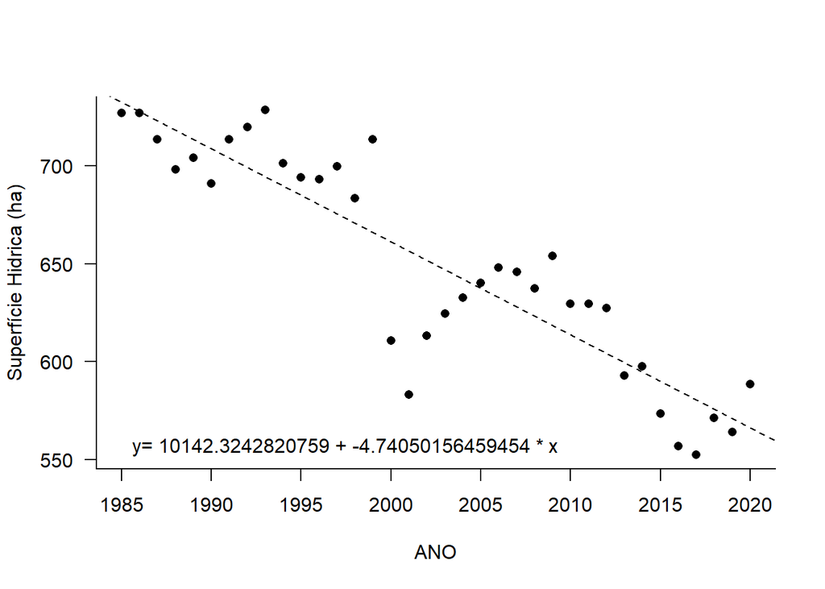

```r
m6 <- glm(WATER_COVERAGE_HA~ANO)
mnulo6 <- glm(WATER_COVERAGE_HA~1)

anova.md6 <- anova(m6, mnulo6, test='F')
summary.m6 <- summary(m6)

dt.modelo6 <- analisamodelo(summary.m6)
modelos <- append(modelos, dt.modelo6)

plot(WATER_COVERAGE_HA~ANO, ylab="Superfície Hidrica (ha)", xlab=dt.modelo6$var_independente, pch=16,las=1,bty="l")

equacao <- dt.modelo6$equacao

abline(m6, lty=2)

legend(x='bottomleft', legend=equacao,bty="n", )
```

```r
lista <- list(analisamodelo(summary.m1),
              analisamodelo(summary.m2),
              analisamodelo(summary.m3),
              analisamodelo(summary.m4),
              analisamodelo(summary.m5),
              analisamodelo(summary.m6)
            )
lista <- do.call(rbind, lista)
lista
```

```
##      Dispersion_parameter Residual_deviance degrees_of_freedom est_intercept
## [1,] 748499.2             25448973          34                 23608.14
## [2,] 13414.72             456100.4          34                 -105901.6
## [3,] 3076422              104598345         34                 464554.3
## [4,] 498.8857             16962.12          34                 5420.768
## [5,] 236.1148             8027.905          34                 -21508.41
## [6,] 636.2092             21631.11          34                 10142.32
##      est_dependente var_dependente var_independente relacao  index
## [1,] 0.7516103      ?              ?                748499.2 1
## [2,] 53.63518       ?              ?                13414.72 1
## [3,] -210.6981      ?              ?                3076422  1
## [4,] -2.364739      ?              ?                498.8857 1
## [5,] 10.92233       ?              ?                236.1148 1
## [6,] -4.740502      ?              ?                636.2092 1
##      equacao
## [1,] "y= 23608.1387894781 + 0.75161027295271 * x"
## [2,] "y= -105901.605084321 + 53.6351846702451 * x"
## [3,] "y= 464554.291321353 + -210.698108170094 * x"
## [4,] "y= 5420.76753325556 + -2.36473864936242 * x"
## [5,] "y= -21508.4122650548 + 10.922331047516 * x"
## [6,] "y= 10142.3242820759 + -4.74050156459454 * x"
```